# Report 1

Advay Vyas

January 16, 2026

# Introduction

I will take a look at Frechet distance, dynamic time warping, and maybe some other metrics and assess how well they might perform and how they work. I’ll then try to implement them into a practice dataset and then the given dataset.

```r
hsa_state = read.csv("hsa_state_inc.csv")
head(hsa_state)
```

```
##     week_end    state hsa_nci_id population_state population_hsa pct_urban
## 1 2022-10-01 Colorado        688          5810774        2948626 0.2345188
## 2 2022-10-01 Colorado        985          5810774          99097 0.1281404
## 3 2022-10-01 Colorado        795          5810774         403427 0.1434707
## 4 2022-10-01 Colorado        754          5810774         775090 0.1742742
## 5 2022-10-01 Colorado        711          5810774         298361 0.2094705
## 6 2022-10-01 Colorado        704          5810774         190064 0.4098567
##    pop_ratio density_state density_hsa area_km2_hsa area_km2_state n_hsa
## 1 0.50744118      21.57111  104.957856    28093.428       269377.6    18
## 2 0.01705401      21.57111    5.843198    16959.378       269377.6    18
## 3 0.06942741      21.57111  201.428352     2002.831       269377.6    18
## 4 0.13338843      21.57111   32.491725    23854.997       269377.6    18
## 5 0.05134617      21.57111    9.462804    31529.873       269377.6    18
## 6 0.03270890      21.57111    8.374817    22694.704       269377.6    18
##   inc_hsa epi_week epi_year season_week  season inc_state
## 1    0.11       39     2022           9 2022/23       0.1
## 2    0.00       39     2022           9 2022/23       0.1
## 3    0.11       39     2022           9 2022/23       0.1
## 4    0.08       39     2022           9 2022/23       0.1
## 5    0.00       39     2022           9 2022/23       0.1
## 6    0.00       39     2022           9 2022/23       0.1
```

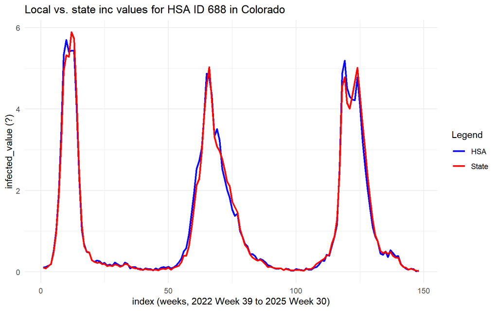

```r
colorado688 = hsa_state[hsa_state$hsa_nci_id == 688, ]

ggplot(colorado688) + geom_line(linewidth = 1, (aes(x = seq_len(148),
    y = inc_hsa, color = "HSA"))) + geom_line(linewidth = 1,
    (aes(x = seq_len(148), y = inc_state, color = "State"))) +
    labs(x = "index (weeks, 2022 Week 39 to 2025 Week 30)", y = "infected_value (?)",
        title = "Local vs. state inc values for HSA ID 688 in Colorado") +
    theme_minimal() + scale_color_manual(name = "Legend", values = c(HSA = "blue",
    State = "red"))
```

# Metrics

## Fréchet distance

I took some brief notes on Fréchet distance. Okay, so it’s a measure of similarity that takes into account time and magnitude, I knew these things. The intuitive definition is a finite curved path with a dog on a leash and the dog has a separate path. The speed can be varied to keep slack in the leash and the Fréchet distance is the shortest possible leash that can traverse both paths while staying as a tether. Formally, it is the infimum of the maximum of the distances between the position of the dog and the position of the owner at time $t$.

The discrete version of Fréchet distance is simplified by considering vertices and providing an efficient approximation. Even though the “leashes” or distances might be usually larger due to a confined set of possible “collars” or points, there are enough time steps (in my opinion) to overcome this. The algorithm for the discrete Fréchet distance is below.

```r
discrete_frechet = function(P, Q, dist_fun = NULL) {
    # P: n x d matrix or data.frame Q: m x d matrix or
    # data.frame dist_fun: function(x, y) returning scalar
    # distance

    if (is.null(dist_fun)) {
        dist_fun = function(x, y) sqrt(sum((x - y)^2))
    }

    P = as.matrix(P)
    Q = as.matrix(Q)

    n = nrow(P)
    m = nrow(Q)

    # distance matrix
    dist_mat = matrix(0, n, m)
    for (i in 1:n) for (j in 1:m) dist_mat[i, j] = dist_fun(P[i,
        ], Q[j, ])

    # DP table
    D = matrix(Inf, n, m)
    Prev = array(NA_integer_, dim = c(n, m, 2))

    # initialization
    D[1, 1] = dist_mat[1, 1]

    for (i in 2:n) {
        D[i, 1] = max(D[i - 1, 1], dist_mat[i, 1])
        Prev[i, 1, ] = c(i - 1, 1)
    }

    for (j in 2:m) {
        D[1, j] = max(D[1, j - 1], dist_mat[1, j])
        Prev[1, j, ] = c(1, j - 1)
    }

    # DP recursion
    for (i in 2:n) {
        for (j in 2:m) {
            candidates = c(D[i - 1, j], D[i, j - 1], D[i - 1,
                j - 1])

            k = which.min(candidates)

            if (k == 1)
                Prev[i, j, ] = c(i - 1, j)
            if (k == 2)
                Prev[i, j, ] = c(i, j - 1)
            if (k == 3)
                Prev[i, j, ] = c(i - 1, j - 1)

            D[i, j] = max(dist_mat[i, j], candidates[k])
        }
    }

    # backtrack optimal path
    i = n
    j = m
    path = matrix(c(i, j), ncol = 2)

    while (!(i == 1 && j == 1)) {
        p = Prev[i, j, ]
        i = p[1]
        j = p[2]
        path = rbind(c(i, j), path)
    }

    # stepwise Frechet values
    step_dist = apply(path, 1, function(idx) dist_mat[idx[1],
        idx[2]])

    frechet_steps = cummax(step_dist)

    list(frechet = D[n, m], path = path, step_distance = step_dist,
        frechet_by_step = frechet_steps)
}
```

Okay, now we convert the “dog” and its “owner” into matrices and run it through the algorithms and plot the leash length over alignment steps.

```r
P = as.matrix(colorado688$inc_hsa)
Q = as.matrix(colorado688$inc_state)

res = discrete_frechet(P, Q)

res$frechet
```

```
## [1] 0.41
```

```r
head(res$frechet_by_step)
```

```
## [1] 0.01 0.02 0.02 0.02 0.02 0.03
```

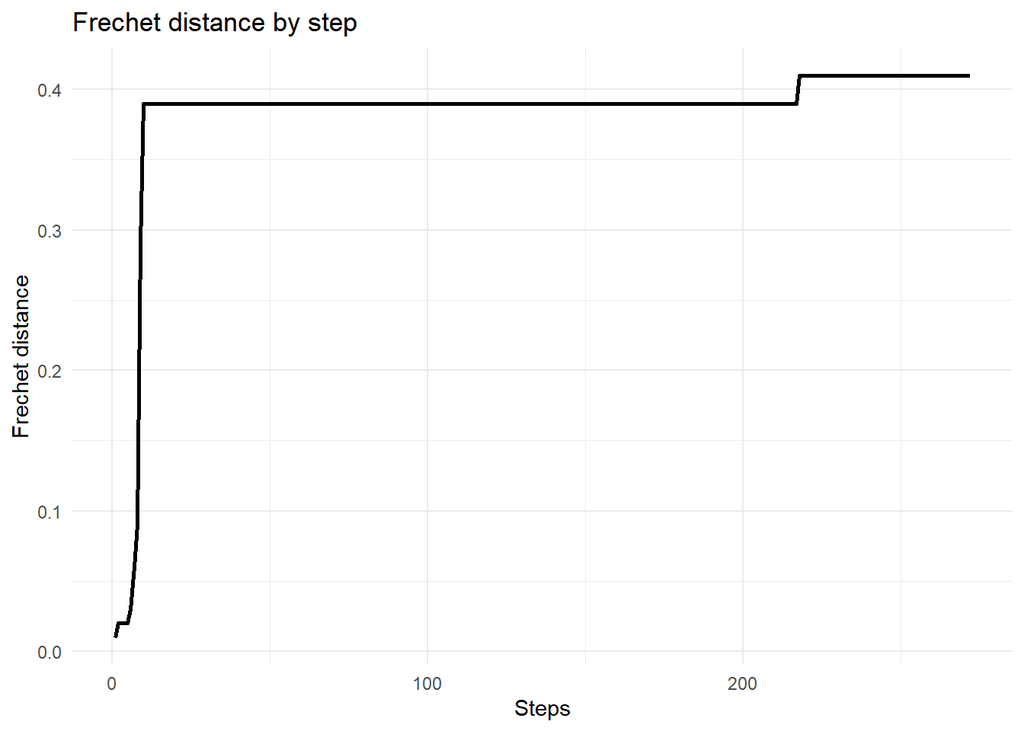

```r
ggplot() + geom_line(aes(x = seq_len(272), y = res$frechet_by_step),
    linewidth = 1) + theme_minimal() + labs(x = "Steps", y = "Frechet distance",
    title = "Frechet distance by step")
```

Looks like the leash length quickly spikes, meaning that initially the forecasts are very similar but then change rapidly. It is kind of hard to interpret this graph without context since I don’t know what regular values for Fréchet distance area. I will try to plot every single HSA and figure it out.

## Dynamic time warping

More notes on the other method, so basically dynamic time warping can “handle” time travel by basically shrinking or squeezing certain periods of time and then from there, it’s easy to check how diffrent the magnitude is. Basically, it calculates an optimal match between two given sequences which has the lowest cost (sum of absolute differences). The sequences are warped non-linearly in the time dimension to look at how different they are as well.

```r
dtw_distance = function(P, Q, dist_fun = NULL) {
    # P, Q: numeric vectors or matrices (rows = time
    # points)
    if (is.null(dist_fun))
        dist_fun = function(x, y) sqrt(sum((x - y)^2))

    P = as.matrix(P)
    Q = as.matrix(Q)

    n = nrow(P)
    m = nrow(Q)

    # distance matrix
    dist_mat = matrix(0, n, m)
    for (i in 1:n) for (j in 1:m) dist_mat[i, j] = dist_fun(P[i,
        ], Q[j, ])

    # cumulative cost matrix
    D = matrix(Inf, n, m)
    D[1, 1] = dist_mat[1, 1]

    # initialize first row/column
    for (i in 2:n) D[i, 1] = dist_mat[i, 1] + D[i - 1, 1]
    for (j in 2:m) D[1, j] = dist_mat[1, j] + D[1, j - 1]

    # fill rest of matrix
    for (i in 2:n) {
        for (j in 2:m) {
            D[i, j] = dist_mat[i, j] + min(D[i - 1, j], D[i,
                j - 1], D[i - 1, j - 1])
        }
    }

    # backtrack optimal path
    i = n
    j = m
    path = matrix(c(i, j), ncol = 2)
    while (!(i == 1 && j == 1)) {
        if (i == 1) {
            j = j - 1
        } else if (j == 1) {
            i = i - 1
        } else {
            # choose minimum predecessor
            k = which.min(c(D[i - 1, j - 1], D[i - 1, j], D[i,
                j - 1]))
            if (k == 1) {
                i = i - 1
                j = j - 1
            } else if (k == 2) {
                i = i - 1
            } else {
                j = j - 1
            }
        }
        path = rbind(c(i, j), path)
    }

    # stepwise cumulative cost along path
    step_cost = dist_mat[path]
    cum_cost = cumsum(step_cost)

    list(dtw_distance = D[n, m], path = path, step_cost = step_cost,
        cum_cost = cum_cost)
}
```

We convert into matrices and run the code and find this graph as the DTW/step.

```r
P = as.matrix(colorado688$inc_hsa)
Q = as.matrix(colorado688$inc_state)

res_dtw = dtw_distance(P, Q)

res_dtw$dtw_distance
```

```
## [1] 11.45
```

```r
head(res_dtw$cum_cost)
```

```
## [1] 0.01 0.04 0.05 0.06 0.09 0.15
```

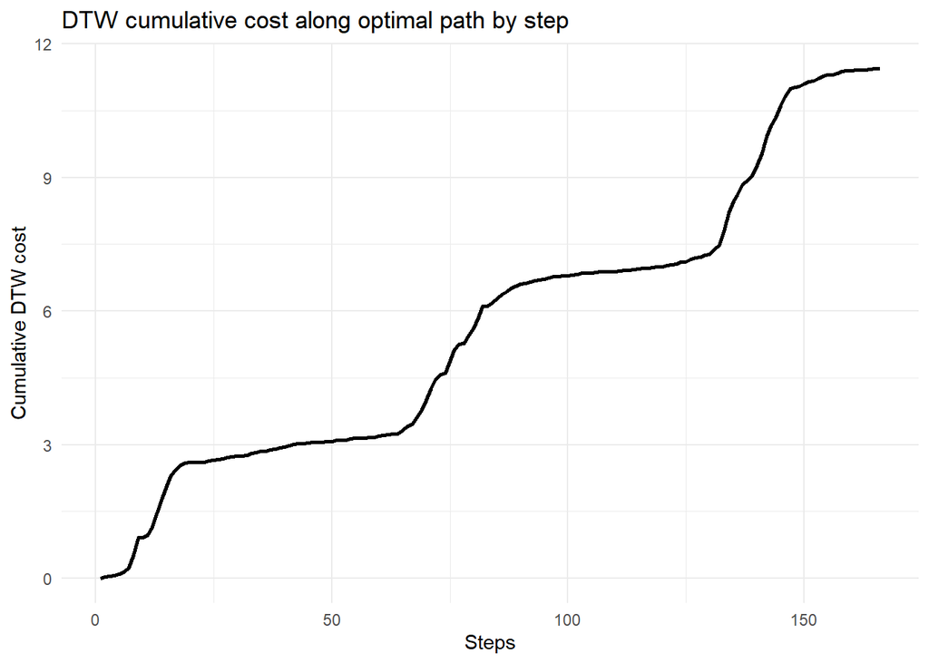

```r
ggplot() + geom_line(aes(x = seq_len(166), y = res_dtw$cum_cost),
    linewidth = 1) + theme_minimal() + labs(x = "Steps", y = "Cumulative DTW cost",
    title = "DTW cumulative cost along optimal path by step")
```

Still need more HSAs for comparison.

# Outlier HSA ID

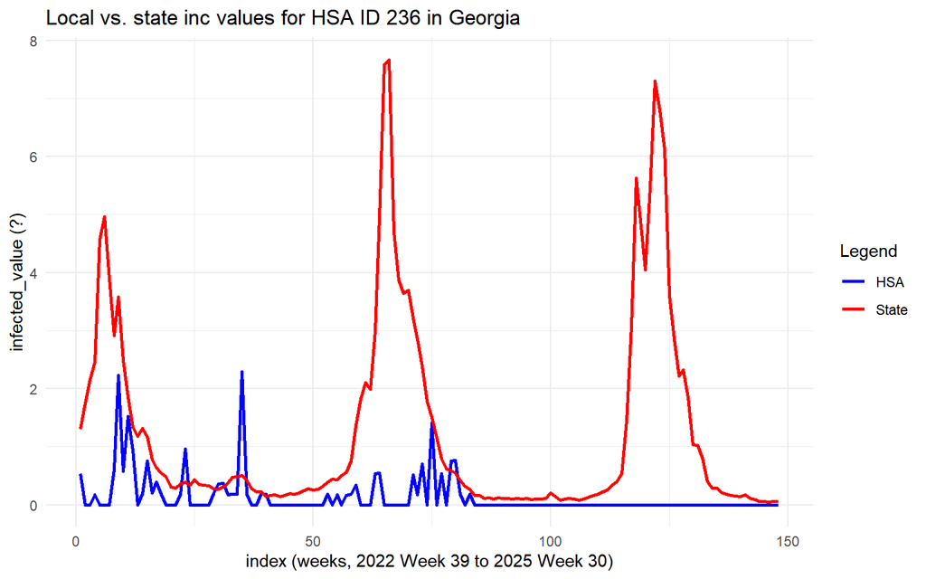

```r
outlier = hsa_state[hsa_state$hsa_nci_id == 236, ]

ggplot(outlier) + geom_line(linewidth = 1, (aes(x = seq_len(148),
    y = inc_hsa, color = "HSA"))) + geom_line(linewidth = 1,
    (aes(x = seq_len(148), y = inc_state, color = "State"))) +
    labs(x = "index (weeks, 2022 Week 39 to 2025 Week 30)", y = "infected_value (?)",
        title = "Local vs. state inc values for HSA ID 236 in Georgia") +
    theme_minimal() + scale_color_manual(name = "Legend", values = c(HSA = "blue",
    State = "red"))
```

```r
P_o = as.matrix(outlier$inc_hsa)
Q_o = as.matrix(outlier$inc_state)
```

```r
res_o = discrete_frechet(P_o, Q_o)

res_o$frechet
```

```
## [1] 5.38
```

```r
head(res_o$frechet_by_step)
```

```
## [1] 0.77 1.31 1.31 1.31 1.31 1.31
```

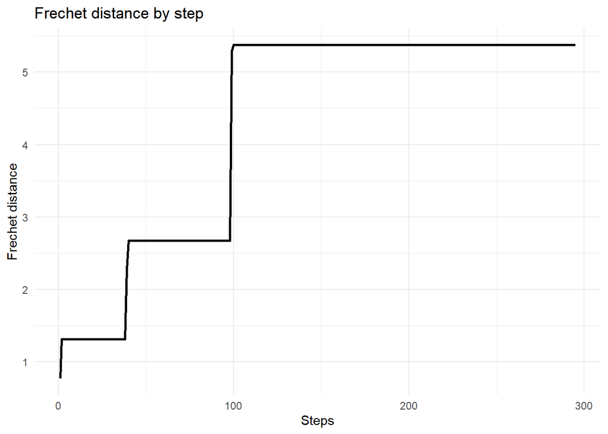

```r
ggplot() + geom_line(aes(x = seq_len(295), y = res_o$frechet_by_step),
    linewidth = 1) + theme_minimal() + labs(x = "Steps", y = "Frechet distance",
    title = "Frechet distance by step")
```

```r
res_dtw_o = dtw_distance(P_o, Q_o)

res_dtw_o$dtw_distance
```

```
## [1] 105.76
```

```r
head(res_dtw_o$cum_cost)
```

```
## [1] 0.77 2.08 3.39 4.53 5.84 7.15
```

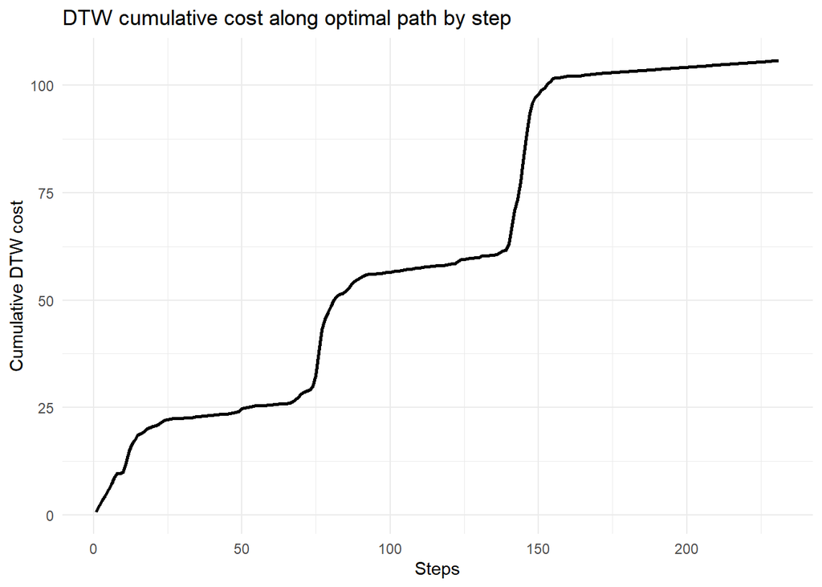

```r
ggplot() + geom_line(aes(x = seq_len(231), y = res_dtw_o$cum_cost),
    linewidth = 1) + theme_minimal() + labs(x = "Steps", y = "Cumulative DTW cost",
    title = "DTW cumulative cost along optimal path by step")
```

# Conclusion

We were able to implement both metrics on the data and test it a few times each. Future work could be running these two metrics for every single row and comparing summary statistics for all of them together to find major differences and if it can understand qualitative differences in curves.